# Line Graph and Pie Chart Assignment

Mike LeVan

2025-03-11

## Line Graph and Pie Chart Assignment

# Homework Assignment: Creating Line Graphs in R using ggplot2

In this assignment, you will create line graphs using the `ggplot2` library in R. You will use built-in datasets from RStudio to visualize different types of data. Ensure you follow the instructions for each problem carefully.

## Problem 1: Line Graph of `pressure` Dataset

**Task:** Create a line graph of the `pressure` dataset, which shows the relationship between temperature and pressure.

**Steps:** 1. Load the `ggplot2` library. 2. Use the `pressure` dataset. 3. Create a line graph with temperature on the x-axis and pressure on the y-axis. 4. Add appropriate labels to the axes and a title to the graph.

**Code Example:**

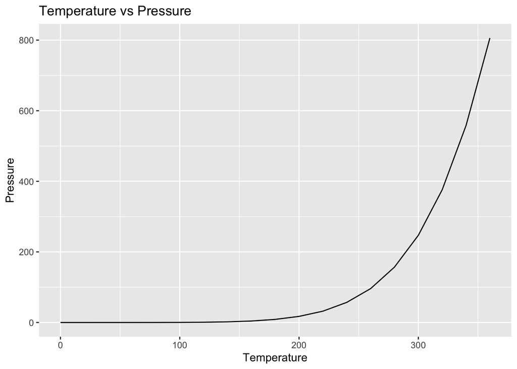

```r
# Load ggplot2 library
library(ggplot2)

# Create line graph
ggplot(pressure, aes(x = temperature, y = pressure)) +
  geom_line() +
  labs(title = "Temperature vs Pressure",
       x = "Temperature",
       y = "Pressure")
```

## Problem 2: Line Graph of `AirPassengers` Dataset

**Task:** Create a line graph of the `AirPassengers` dataset, which shows the number of air passengers over time.

**Steps:** 1. Load the `ggplot2` library. 2. Use the `AirPassengers` dataset. 3. Convert the `AirPassengers` time series object to a data frame. 4. Create a line graph with time on the x-axis and the number of passengers on the y-axis. 5. Add appropriate labels to the axes and a title to the graph.

**Code Example:**

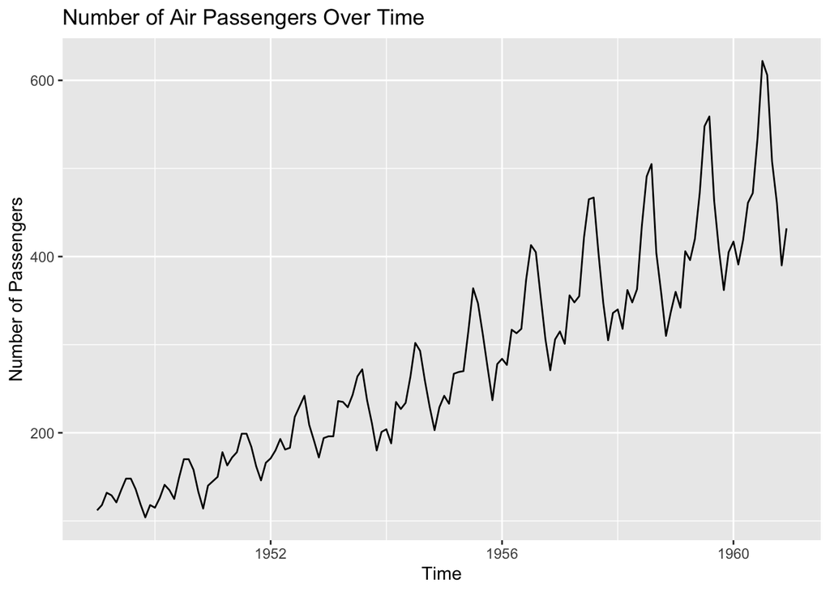

```r
# Load ggplot2 library
library(ggplot2)

# Convert AirPassengers to data frame
airpassengers_df <- data.frame(
  time = time(AirPassengers),
  passengers = as.numeric(AirPassengers)
)

# Create line graph
ggplot(airpassengers_df, aes(x = time, y = passengers)) +
  geom_line() +
  labs(title = "Number of Air Passengers Over Time",
       x = "Time",
       y = "Number of Passengers")
```

## Problem 3: Line Graph of `lynx` Dataset

**Task:** Create a line graph of the `lynx` dataset, which shows the annual numbers of lynx trappings from 1821–1934 in Canada.

**Steps:** 1. Load the `ggplot2` library. 2. Use the `lynx` dataset. 3. Convert the `lynx` time series object to a data frame. 4. Create a line graph with time on the x-axis and the number of lynx trapped on the y-axis. 5. Add appropriate labels to the axes and a title to the graph.

**Code Example:**

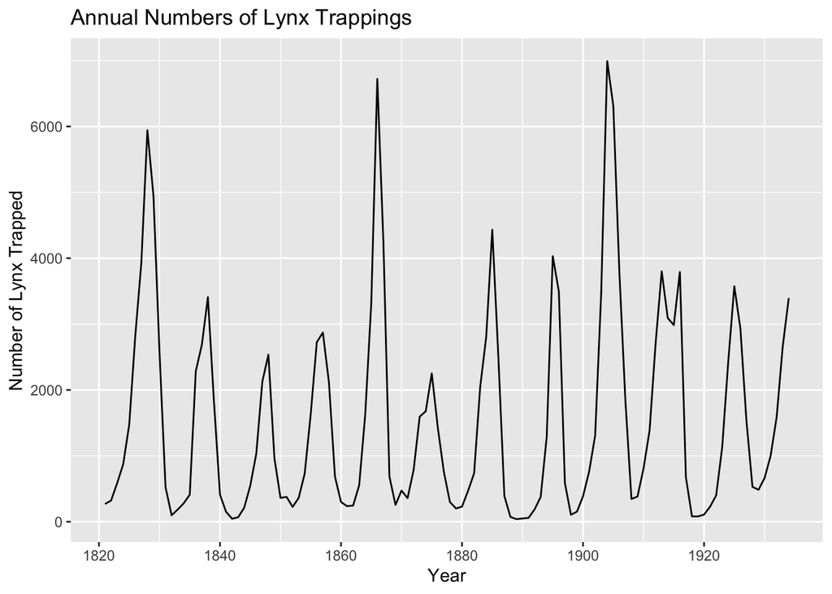

```r
# Load ggplot2 library
library(ggplot2)

# Convert lynx to data frame
lynx_df <- data.frame(
  year = time(lynx),
  trappings = as.numeric(lynx)
)

# Create line graph
ggplot(lynx_df, aes(x = year, y = trappings)) +
  geom_line() +
  labs(title = "Annual Numbers of Lynx Trappings",
       x = "Year",
       y = "Number of Lynx Trapped")
```

## Problem 4: Line Graph of `economics` Dataset

**Task:** Create a line graph of the `economics` dataset, which shows the unemployment rate over time.

**Steps:** 1. Load the `ggplot2` library. 2. Use the `economics` dataset. 3. Create a line graph with date on the x-axis and unemployment rate (`unemploy/pop * 100`) on the y-axis. 4. Add appropriate labels to the axes and a title to the graph.

**Code Example:**

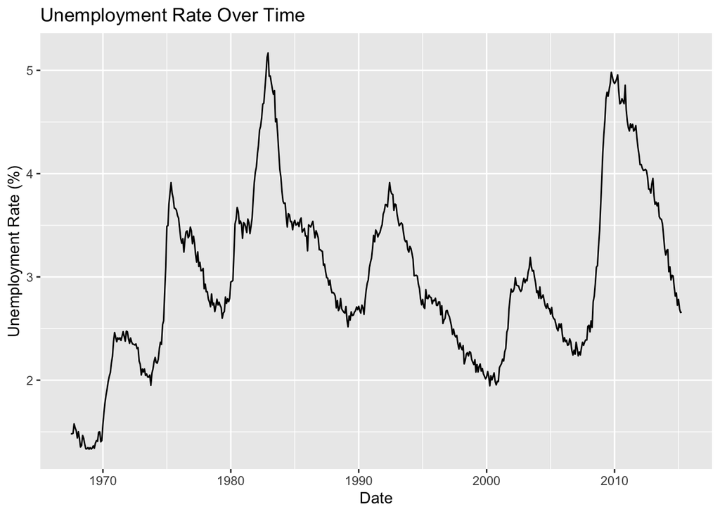

```r
# Load ggplot2 library
library(ggplot2)

# Create line graph
ggplot(economics, aes(x = date, y = unemploy / pop * 100)) +
  geom_line() +
  labs(title = "Unemployment Rate Over Time",
       x = "Date",
       y = "Unemployment Rate (%)")
```

## Problem 5: Line Graph of `co2` Dataset

**Task:** Create a line graph of the `co2` dataset, which shows the concentration of atmospheric carbon dioxide over time.

**Steps:** 1. Load the `ggplot2` library. 2. Use the `co2` dataset. 3. Convert the `co2` time series object to a data frame. 4. Create a line graph with time on the x-axis and CO2 concentration on the y-axis. 5. Add appropriate labels to the axes and a title to the graph.

**Code Example:**

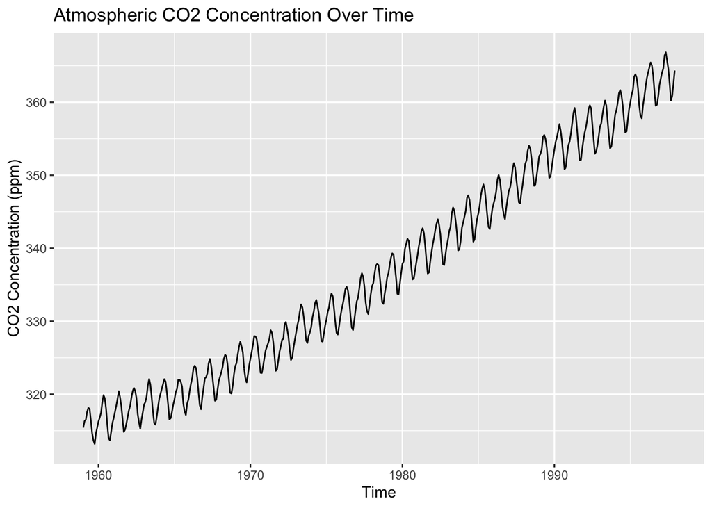

```r
# Load ggplot2 library
library(ggplot2)

# Convert co2 to data frame
co2_df <- data.frame(
  time = time(co2),
  concentration = as.numeric(co2)
)

# Create line graph
ggplot(co2_df, aes(x = time, y = concentration)) +
  geom_line() +
  labs(title = "Atmospheric CO2 Concentration Over Time",
       x = "Time",
       y = "CO2 Concentration (ppm)")
```

## Problem 1: Pie Chart of Species Distribution in the Iris Dataset

**Objective:** Create a pie chart to visualize the distribution of different species in the Iris dataset.

**Steps:** 1. Load the `ggplot2` library. 2. Use the built-in `iris` dataset. 3. Create a data frame that counts the number of occurrences of each species. 4. Use `ggplot2` to create a pie chart displaying the species distribution.

**Hints:** - Use `table` to count the occurrences of each species. - Use `geom_bar` and `coord_polar` to create the pie chart.

**Code Example:**

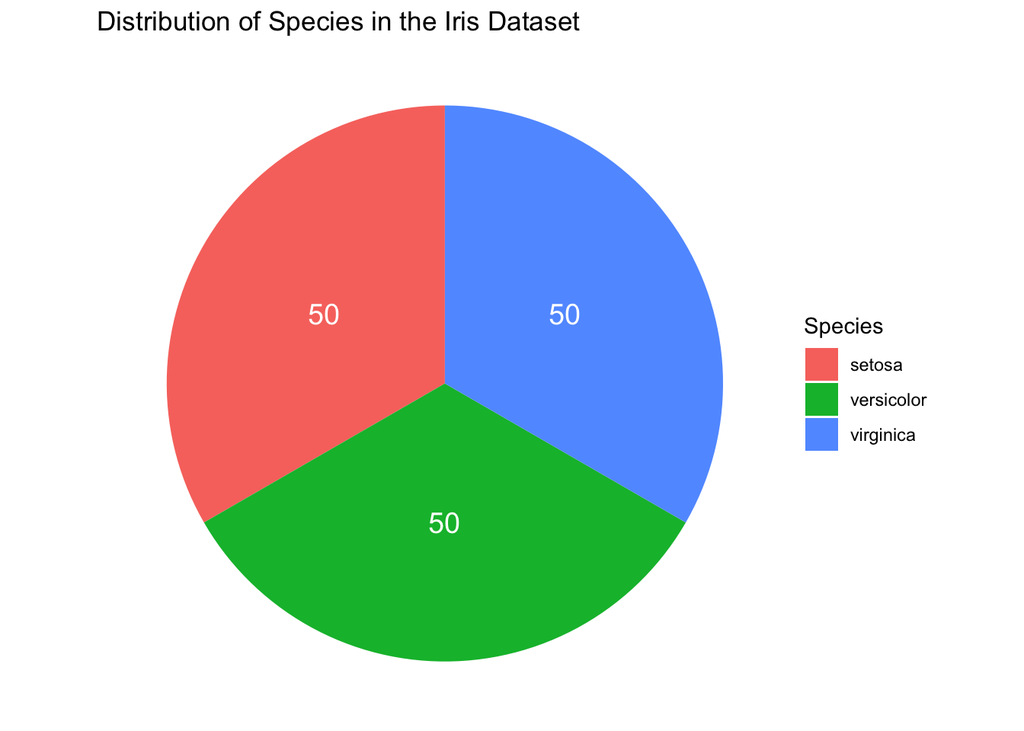

```r
# Load ggplot2
library(ggplot2)

# Load iris dataset
data(iris)

# Count species occurrences
species_count <- as.data.frame(table(iris$Species))

# Create pie chart
ggplot(species_count, aes(x = "", y = Freq, fill = Var1)) +
  geom_bar(stat = "identity", width = 1) +
  coord_polar(theta = "y") +
  geom_text(aes(label = Freq),
        position = position_stack(vjust = 0.5),
        color = "white", size = 5) +
  theme_void() +
  ggtitle("Distribution of Species in the Iris Dataset") +
  labs(fill = "Species")
```

## Problem 2: Pie Chart of Gear Distribution in the Cars Dataset

**Hints:** - Use `table` to count the occurrences of each gear type. - Use `geom_bar` and `coord_polar` to create the pie chart.

**Code Example:**

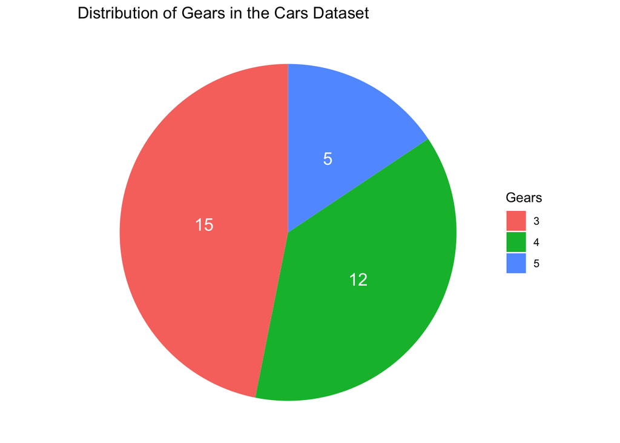

```r
# Load ggplot2
library(ggplot2)

# Load cars dataset
data(mtcars)

# Count gear occurrences
gear_count <- as.data.frame(table(mtcars$gear))

# Create pie chart

ggplot(gear_count, aes(x = "", y = Freq, fill = Var1)) +
  geom_bar(stat = "identity", width = 1) +
  coord_polar(theta = "y") +
  geom_text(aes(label = Freq),
        position = position_stack(vjust = 0.5),
        color = "white", size = 5) +
  theme_void() +
  ggtitle("Distribution of Gears in the Cars Dataset") +
  labs(fill = "Gears")
```

## Problem 3: Pie Chart of Titanic Class Distribution in the Titanic Dataset

**Objective:** Create a pie chart to visualize the distribution of different classes in the `Titanic` dataset.

**Steps:** 1. Load the `ggplot2` library. 2. Use the built-in `Titanic` dataset. 3. Create a data frame that counts the number of occurrences of each class. 4. Use `ggplot2` to create a pie chart displaying the class distribution.

**Hints:** - Use `table` to count the occurrences of each class. - Use `geom_bar` and `coord_polar` to create the pie chart.

**Code Example:**

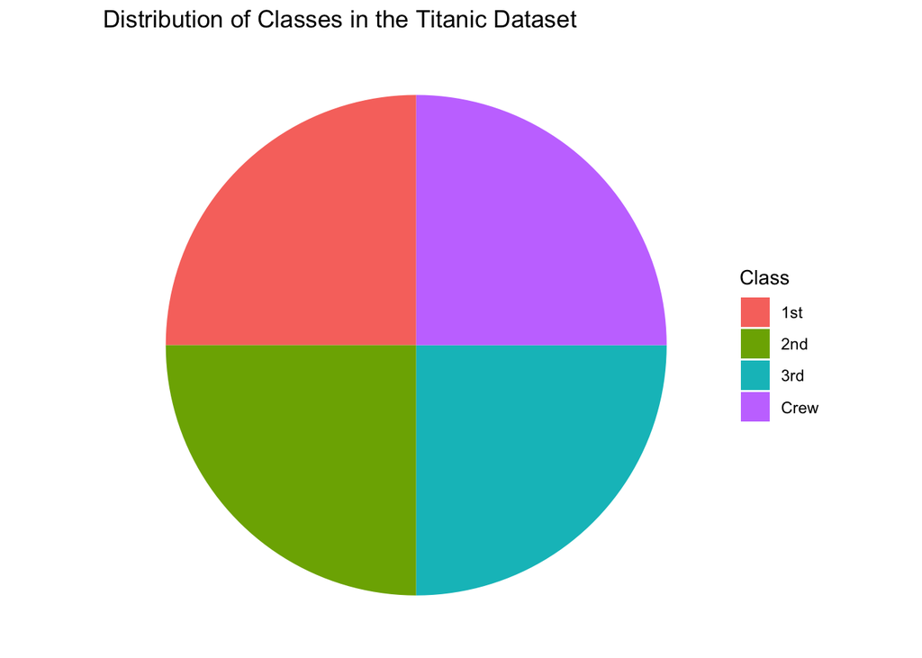

```r
# Load ggplot2
library(ggplot2)

# Load Titanic dataset
data(Titanic)

# Convert Titanic dataset to data frame
titanic_df <- as.data.frame(Titanic)

# Count class occurrences
class_count <- as.data.frame(table(titanic_df$Class))

# Create pie chart
ggplot(class_count, aes(x = "", y = Freq, fill = Var1)) +
  geom_bar(stat = "identity", width = 1) +
  coord_polar(theta = "y") +
  theme_void() +
  ggtitle("Distribution of Classes in the Titanic Dataset") +
  labs(fill = "Class")
```

## Problem 4: Pie Chart of Supplement Distribution in the `ToothGrowth` Dataset

**Task:** Create a pie chart to show the distribution of the different supplements (VC and OJ) in the `ToothGrowth` dataset.

**Steps:** 1. Load the `ggplot2` library and the `ToothGrowth` dataset. 2. Create a data frame that summarizes the count of each supplement type. 3. Use `ggplot2` to create a pie chart that shows the proportion of each supplement.

**Hint:** Use the `fill` aesthetic to map the `supp` column to the pie chart slices.

**Code Example:**

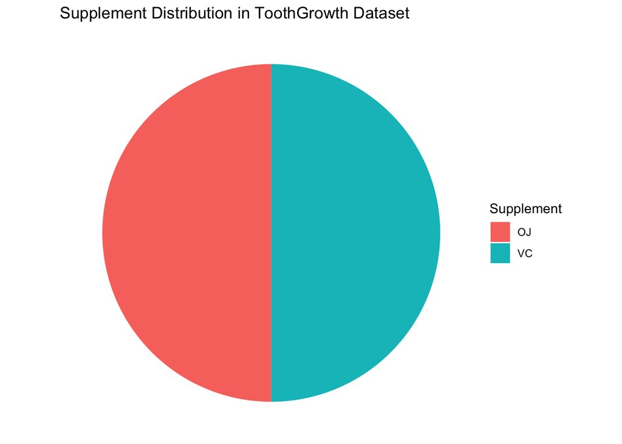

```r
# Load ggplot2 and ToothGrowth dataset
library(ggplot2)
data(ToothGrowth)

# Summarize count of each supplement type
supp_count <- as.data.frame(table(ToothGrowth$supp))

# Create pie chart
ggplot(supp_count, aes(x = "", y = Freq, fill = Var1)) +
  geom_bar(stat = "identity", width = 1) +
  coord_polar(theta = "y") +
  labs(title = "Supplement Distribution in ToothGrowth Dataset", fill = "Supplement") +
  theme_void()
```

## Problem 5: Pie Chart of Education Levels in the `infert` Dataset

**Task:** Create a pie chart to show the distribution of different education levels in the `infert` dataset.

**Steps:** 1. Load the `ggplot2` library and the `infert` dataset. 2. Create a data frame that summarizes the count of each education level. 3. Use `ggplot2` to create a pie chart that shows the proportion of each education level.

**Hint:** Use the `fill` aesthetic to map the `education` column to the pie chart slices.

**Code Example:**

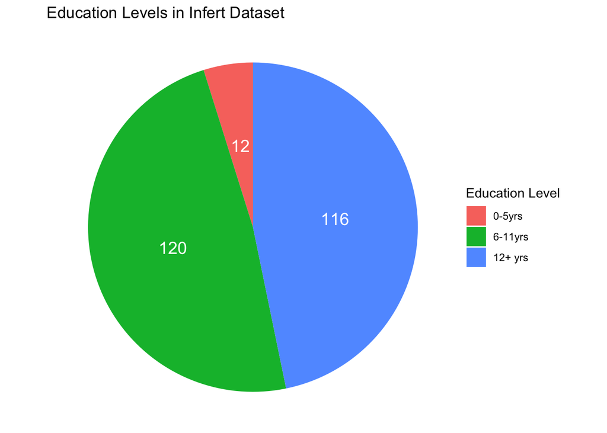

```r
# Load ggplot2 and infert dataset
library(ggplot2)
data(infert)

# Summarize count of each education level
education_count <- as.data.frame(table(infert$education))

# Create pie chart
ggplot(education_count, aes(x = "", y = Freq, fill = Var1)) +
  geom_bar(stat = "identity", width = 1) +
  coord_polar(theta = "y") +
  geom_text(aes(label = Freq),
        position = position_stack(vjust = 0.5),
        color = "white", size = 5) +
  labs(title = "Education Levels in Infert Dataset", fill = "Education Level") +
  theme_void()
```